# aditividade

Iago

29/03/2021

# Dados brutos

Gráfico dos efeitos da interação trat : bloco:

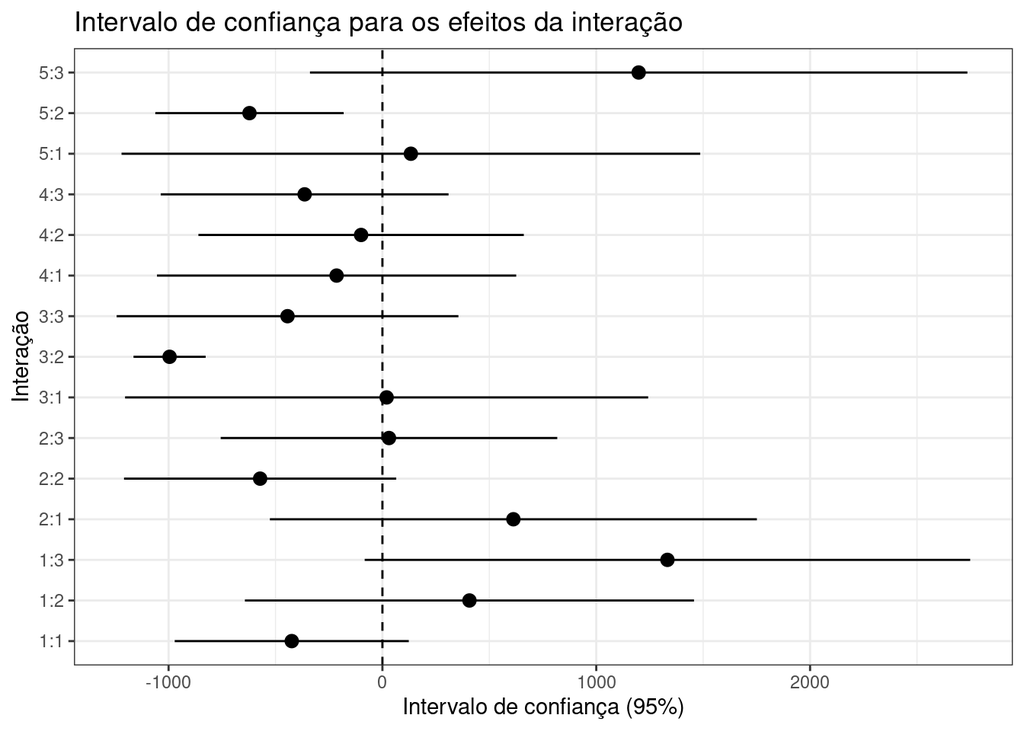

```r
medias <- armadilhas%>%
  group_by(trat,bloco)%>%
  summarise(media=mean(moscab),sd=sd(moscab))
medias$efeito <- medias$media-mean(moscab)
medias$cl <- medias$efeito-1.96*(medias$sd/3)
medias$cu <- medias$efeito+1.96*(medias$sd/3)

fp <- ggplot(data=medias, aes(x=trat:bloco, y=efeito, ymin=cl, ymax=cu)) +
        geom_pointrange() +
        geom_hline(yintercept=0, lty=2) +  # add a dotted line at x=1 after flip
        coord_flip() +  # flip coordinates (puts labels on y axis)
        xlab("Interação") + ylab("Intervalo de confiança (95%)") + ggtitle("Intervalo de confiança para os efeitos da interação")+ theme_bw()  # use a white background
print(fp)
```

Note que apenas o efeito das interações tratamento 3 e bloco 2 e tratamento 5 e bloco 2 não incluem o 0 em seu intervalo de confiança de 95%.

Para o teste de aditividade a seguir, fiz as médias das interações sem levar em contas as medidas repetidas.

```r
#armadilhas dados brutos média
options(dplyr.summarise.inform = FALSE)
matriz <- armadilhas%>%
  group_by(trat,bloco)%>%
  summarise(media=mean(moscab))
matriz
mod <- aov(media~trat+bloco,data=matriz)
car:::tukeyNonaddTest(mod)
```

```
## # A tibble: 15 x 3
## # Groups:   trat [5]
##    trat  bloco media
##    <fct> <fct> <dbl>
##  1 1     1     1054.
##  2 1     2     1885.
##  3 1     3     2811
##  4 2     1     2091.
##  5 2     2      906.
##  6 2     3     1509.
##  7 3     1     1498.
##  8 3     2      483.
##  9 3     3     1034.
## 10 4     1     1264.
## 11 4     2     1378.
## 12 4     3     1114.
## 13 5     1     1611.
## 14 5     2      856.
## 15 5     3     2677.
##      Test    Pvalue
## 0.8981757 0.3690919
```

O teste de aditividade não rejeita a hipótese nula. Portanto, não há evidências para rejeitar a hipótese de aditividade entre tratamentos e blocos.

```r
#armadilhas dados inteiros
mod <- aov(moscab~trat+bloco,data=armadilhas)
car:::tukeyNonaddTest(mod)
```

```
##      Test    Pvalue
## 1.1352699 0.2562622
```

Com os dados inteiros também não é possível rejeitar a hipótese de aditividade.

```r
for(i in 1:9){
  semana <- armadilhas[armadilhas$semana==i,]
  mod <- aov(moscab~trat+bloco,data=semana)
teste <- car:::tukeyNonaddTest(mod)
# p-valor é menor que 0.05?
print(teste[2]<0.05)
  }
```

```
## Pvalue
##  FALSE
## Pvalue
##  FALSE
## Pvalue
##  FALSE
## Pvalue
##  FALSE
## Pvalue
##  FALSE
## Pvalue
##  FALSE
## Pvalue
##  FALSE
## Pvalue
##   TRUE
## Pvalue
##  FALSE
```

Apenas na semana 8 os efeitos não são aditivos.

Não fiquei satisfeito com esse resultado, então fiz no SAS um teste de tukey para aditividade (beaseado nesse artigo https://www.lexjansen.com/scsug/1992/SCSUG92035.pdf) considerando medidas repetidas e o resultado foi:

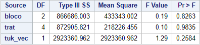

Com p-valor 0.25, não é possível rejeitar a hipótese de aditividade para as armadilhas com dados brutos

# Ranques

Gráfico dos efeitos da interação trat : bloco:

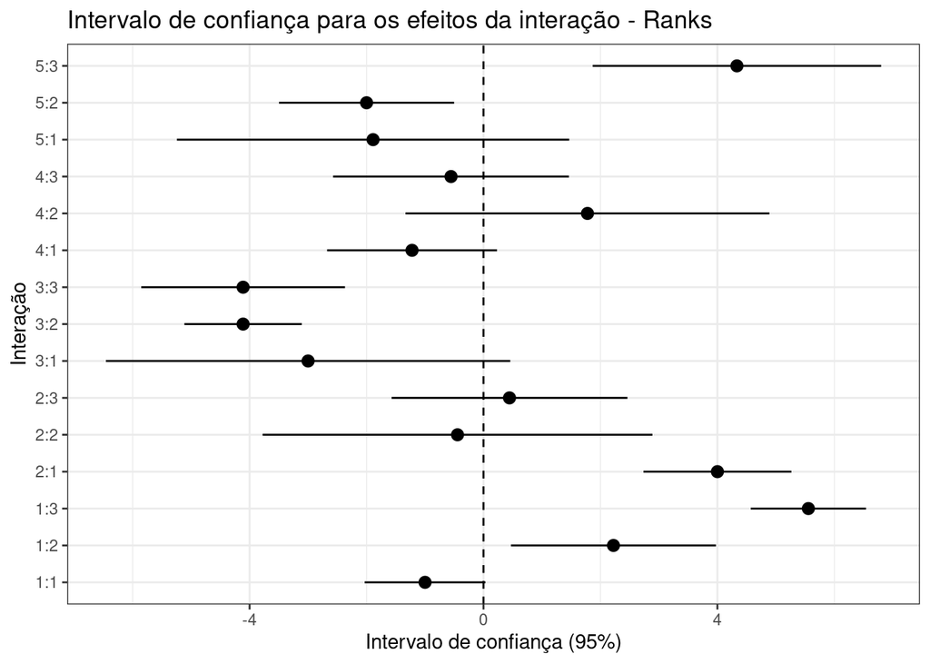

```r
medias <- armadilhas%>%
  group_by(trat,bloco)%>%
  summarise(media=mean(rank),sd=sd(rank))
medias$efeito <- medias$media-mean(rank)
medias$cl <- medias$efeito-1.96*(medias$sd/3)
medias$cu <- medias$efeito+1.96*(medias$sd/3)

fp <- ggplot(data=medias, aes(x=trat:bloco, y=efeito, ymin=cl, ymax=cu)) +
        geom_pointrange() +
        geom_hline(yintercept=0, lty=2) +  # add a dotted line at x=1 after flip
        coord_flip() +  # flip coordinates (puts labels on y axis)
        xlab("Interação") + ylab("Intervalo de confiança (95%)") + ggtitle("Intervalo de confiança para os efeitos da interação - Ranks")+
        theme_bw()  # use a white background
print(fp)
```

Note que 7 das 15 interações não possuem o 0 em seu intervalo de confiança. Teste de adtividade sem as medidas repetidas:

```r
#armadilhas dados brutos média por semana
options(dplyr.summarise.inform = FALSE)
matriz <- armadilhas%>%
  group_by(trat,bloco)%>%
  summarise(media=mean(rank))
matriz
mod <- aov(media~trat+bloco,data=matriz)
car:::tukeyNonaddTest(mod)
```

```
## # A tibble: 15 x 3
## # Groups:   trat [5]
##    trat  bloco media
##    <fct> <fct> <dbl>
##  1 1     1      7
##  2 1     2     10.2
##  3 1     3     13.6
##  4 2     1     12
##  5 2     2      7.56
##  6 2     3      8.44
##  7 3     1      5
##  8 3     2      3.89
##  9 3     3      3.89
## 10 4     1      6.78
## 11 4     2      9.78
## 12 4     3      7.44
## 13 5     1      6.11
## 14 5     2      6
## 15 5     3     12.3
##      Test    Pvalue
## 0.8467162 0.3971533
```

```r
#armadilhas dados inteiros
mod <- aov(rank~trat+bloco,data=armadilhas)
car:::tukeyNonaddTest(mod)
```

```
##       Test     Pvalue
## 1.78920076 0.07358249
```

Novamente, não há evidências para rejeitar a hipótese de aditividade.

Teste de aditividade semanal

```r
for(i in 1:9){
  semana <- armadilhas[armadilhas$semana==i,]
  mod <- aov(rank~trat+bloco,data=semana)
teste <- car:::tukeyNonaddTest(mod)
# p-valor é menor que 0.05?
print(teste[2]<0.05)
  }
```

```
## Pvalue
##  FALSE
## Pvalue
##  FALSE
## Pvalue
##  FALSE
## Pvalue
##  FALSE
## Pvalue
##  FALSE
## Pvalue
##  FALSE
## Pvalue
##  FALSE
## Pvalue
##   TRUE
## Pvalue
##   TRUE
```

Em duas das 9 semanas houve evidência para rejeitar a hipótese de aditividade.

Pelo teste incluindo as medidas repetidas, temos:

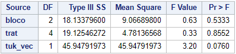

Não é possível rejeitar a hipótese de aditividade para os ranks.

## Plantas

Gráfico dos efeitos da interação trat : bloco:

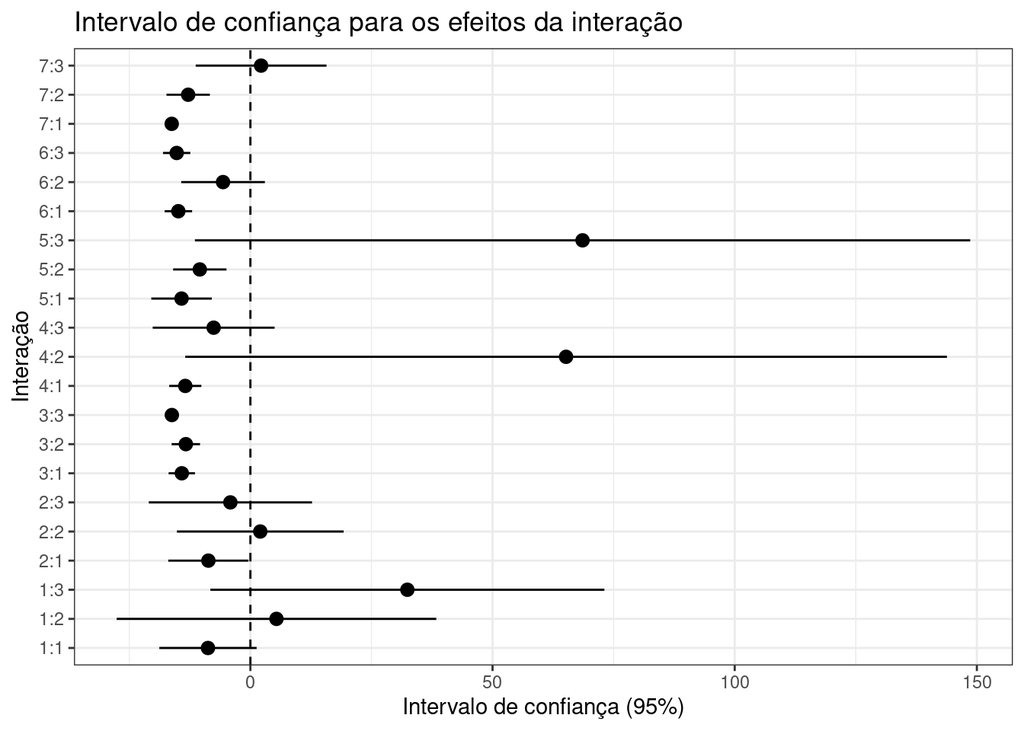

```r
medias <- plantas%>%
  group_by(trat,bloco)%>%
  summarise(media=mean(moscab),sd=sd(moscab))
medias$efeito <- medias$media-mean(moscab)
medias$cl <- medias$efeito-1.96*(medias$sd/sqrt(7))
medias$cu <- medias$efeito+1.96*(medias$sd/sqrt(7))

fp <- ggplot(data=medias, aes(x=trat:bloco, y=efeito, ymin=cl, ymax=cu)) +
        geom_pointrange() +
        geom_hline(yintercept=0, lty=2) +  # add a dotted line at x=1 after flip
        coord_flip() +  # flip coordinates (puts labels on y axis)
        xlab("Interação") + ylab("Intervalo de confiança (95%)") + ggtitle("Intervalo de confiança para os efeitos da interação")+
        theme_bw()  # use a white background
print(fp)
```

A maioria dos intervalos de confiança para os efeitos de interação nas plantas não contém o valor 0.

```r
#Plantas dados brutos média
options(dplyr.summarise.inform = FALSE)
matriz <- plantas%>%
  group_by(trat,bloco)%>%
  summarise(media=mean(moscab))
matriz
mod <- aov(media~trat+bloco,data=matriz)
car:::tukeyNonaddTest(mod)
```

```
## # A tibble: 21 x 3
## # Groups:   trat [7]
##    trat  bloco media
##    <fct> <fct> <dbl>
##  1 1     1      8.54
##  2 1     2     22.7
##  3 1     3     49.7
##  4 2     1      8.63
##  5 2     2     19.3
##  6 2     3     13.2
##  7 3     1      3.14
##  8 3     2      3.97
##  9 3     3      1.09
## 10 4     1      3.86
## # … with 11 more rows
##      Test    Pvalue
## 1.5301411 0.1259818
```

```r
#plantas dados inteiros
mod <- aov(moscab~trat+bloco,data=plantas)
car:::tukeyNonaddTest(mod)
```

```
##         Test       Pvalue
## 5.199611e+00 1.997065e-07
```

Pelo teste desconsiderando as medidas repetidas, não há indícios para rejeitar a hipótese de aditividade.

Teste de aditividade semanal

```r
for(i in 1:7){
  semana <- plantas[plantas$semana==i,]
  mod <- aov(moscab~trat+bloco,data=semana)
teste <- car:::tukeyNonaddTest(mod)
# p-valor é menor que 0.05?
print(teste[2]<0.05)
  }
```

```
## Pvalue
##  FALSE
## Pvalue
##  FALSE
## Pvalue
##   TRUE
## Pvalue
##   TRUE
## Pvalue
##   TRUE
## Pvalue
##   TRUE
## Pvalue
##   TRUE
```

Os efeitos não são aditivos em 5 das 7 semanas.

Pelo teste incluindo as medidas repetidas, temos:

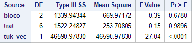

Com p-valor <0.001, rejeita-se a hipótese de aditividade dos efeitos tratamentos e blocos para os dados de plantas.

# Ranques

Gráfico dos efeitos da interação trat : bloco:

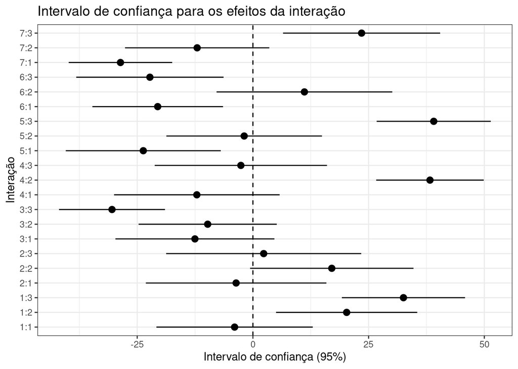

```r
medias <- plantas%>%
  group_by(trat,bloco)%>%
  summarise(media=mean(rank),sd=sd(rank))
medias$efeito <- medias$media-mean(rank)
medias$cl <- medias$efeito-1.96*(medias$sd/sqrt(7))
medias$cu <- medias$efeito+1.96*(medias$sd/sqrt(7))

fp <- ggplot(data=medias, aes(x=trat:bloco, y=efeito, ymin=cl, ymax=cu)) +
        geom_pointrange() +
        geom_hline(yintercept=0, lty=2) +  # add a dotted line at x=1 after flip
        coord_flip() +  # flip coordinates (puts labels on y axis)
        xlab("Interação") + ylab("Intervalo de confiança (95%)") + ggtitle("Intervalo de confiança para os efeitos da interação")+
        theme_bw()  # use a white background
print(fp)
```

```r
#Plantas dados brutos média
options(dplyr.summarise.inform = FALSE)
matriz <- plantas%>%
  group_by(trat,bloco)%>%
  summarise(media=mean(rank))
matriz
mod <- aov(media~trat+bloco,data=matriz)
car:::tukeyNonaddTest(mod)
```

```
## # A tibble: 21 x 3
## # Groups:   trat [7]
##    trat  bloco media
##    <fct> <fct> <dbl>
##  1 1     1      49.0
##  2 1     2      73.3
##  3 1     3      85.5
##  4 2     1      49.4
##  5 2     2      70.0
##  6 2     3      55.3
##  7 3     1      40.5
##  8 3     2      43.2
##  9 3     3      22.6
## 10 4     1      40.9
## # … with 11 more rows
##      Test    Pvalue
## 1.0681024 0.2854743
```

```r
#armadilhas dados inteiros
mod <- aov(rank~trat+bloco,data=plantas)
car:::tukeyNonaddTest(mod)
```

```
##         Test       Pvalue
## 4.667944e+00 3.042284e-06
```

Teste de aditividade semanal

```r
for(i in 1:7){
  semana <- plantas[plantas$semana==i,]
  mod <- aov(rank~trat+bloco,data=semana)
teste <- car:::tukeyNonaddTest(mod)
# p-valor é menor que 0.05?
print(teste[2]<0.05)
  }
```

```
## Pvalue
##   TRUE
## Pvalue
##  FALSE
## Pvalue
##   TRUE
## Pvalue
##  FALSE
## Pvalue
##  FALSE
## Pvalue
##  FALSE
## Pvalue
##   TRUE
```

Em nenhuma semana a hipótese de aditividade é rejeitada em 4 das 7 semanas.

Pelo teste incluindo as medidas repetidas, temos:

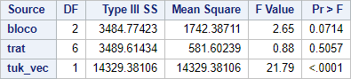

Com p-valor <0.001 a hipótese de aditividade é rejeitada.

### Transformação de BoxCox

Como sugerido em alguns artigos que encontrei, a transformação de BoxCox é útil para se corrigir a não aditividade. Fazendo os cálculos para os dados brutos de Plantas, obtemos um valor de transformação igual a 0.063.

Com os valores transformados, os testes de aditividade mudaram o resultado:

```r
plantas$moscab2 <- ((plantas$moscab**0.063)-1)/0.063
#armadilhas dados inteiros
mod <- aov(moscab2~trat+bloco,data=plantas)
car:::tukeyNonaddTest(mod)
```

```
##      Test    Pvalue
## 1.5459946 0.1221059
```

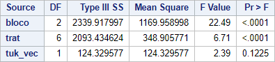

Porém, na Análise de variância por medidas repetidas o fator de interação trat:bloco continua significativo.

```r
#modelo sem transformação
modelo <- aov(moscab ~ (trat *bloco) * semana + Error(sujeito/semana), data=plantas)
summary(modelo)
```

```
##
## Error: sujeito
##            Df Sum Sq Mean Sq F value   Pr(>F)
## trat        6 102049   17008   19.16 6.14e-14 ***
## bloco       2  63473   31736   35.74 5.87e-12 ***
## trat:bloco 12 265484   22124   24.92  < 2e-16 ***
## Residuals  84  74584     888
## ---
## Signif. codes:  0 '***' 0.001 '**' 0.01 '*' 0.05 '.' 0.1 ' ' 1
##
## Error: sujeito:semana
##                    Df Sum Sq Mean Sq F value   Pr(>F)
## semana              6  96889   16148  14.271 4.77e-15 ***
## trat:semana        36  90594    2517   2.224 8.91e-05 ***
## bloco:semana       12  34722    2893   2.557  0.00272 **
## trat:bloco:semana  72 163415    2270   2.006 8.81e-06 ***
## Residuals         504 570294    1132
## ---
## Signif. codes:  0 '***' 0.001 '**' 0.01 '*' 0.05 '.' 0.1 ' ' 1
```

```r
#modelo com transformação
modelo1 <- aov(moscab2 ~ (trat *bloco) * semana + Error(sujeito/semana), data=plantas)
summary(modelo1)
```

```
##
## Error: sujeito
##            Df Sum Sq Mean Sq F value   Pr(>F)
## trat        6   2646   440.9   7.777 1.15e-06 ***
## bloco       2   3266  1632.8  28.799 2.99e-10 ***
## trat:bloco 12   5310   442.5   7.805 1.51e-09 ***
## Residuals  84   4763    56.7
## ---
## Signif. codes:  0 '***' 0.001 '**' 0.01 '*' 0.05 '.' 0.1 ' ' 1
##
## Error: sujeito:semana
##                    Df Sum Sq Mean Sq F value   Pr(>F)
## semana              6   2293   382.1  10.759 2.85e-11 ***
## trat:semana        36   1314    36.5   1.027   0.4280
## bloco:semana       12    765    63.7   1.794   0.0463 *
## trat:bloco:semana  72   5492    76.3   2.148 1.03e-06 ***
## Residuals         504  17902    35.5
## ---
## Signif. codes:  0 '***' 0.001 '**' 0.01 '*' 0.05 '.' 0.1 ' ' 1
```

Modelo sem interações:

```r
modelo_add <- aov(moscab2 ~ (trat +bloco) * semana + Error(sujeito/semana), data=plantas)
summary(modelo_add)
```

```
##
## Error: sujeito
##           Df Sum Sq Mean Sq F value   Pr(>F)
## trat       6   2646   440.9   4.202 0.000851 ***
## bloco      2   3266  1632.8  15.561  1.4e-06 ***
## Residuals 96  10073   104.9
## ---
## Signif. codes:  0 '***' 0.001 '**' 0.01 '*' 0.05 '.' 0.1 ' ' 1
##
## Error: sujeito:semana
##               Df Sum Sq Mean Sq F value   Pr(>F)
## semana         6   2293   382.1   9.409 7.23e-10 ***
## trat:semana   36   1314    36.5   0.898   0.6411
## bloco:semana  12    765    63.7   1.569   0.0964 .
## Residuals    576  23394    40.6
## ---
## Signif. codes:  0 '***' 0.001 '**' 0.01 '*' 0.05 '.' 0.1 ' ' 1
```

O modelo sem interação respeita a suposição de esfericidade. Não respeita a normalidade nem homocedasticidade. É necessário usar os ranques.

Para os ranques não consegui uma transfromação BoxCox que satisfaça a aditividade. Na verdade, não sei nem se faz sentido transformar ranques por BoxCox. O mais perto de uma situação de aditividade entre os ranques foi por meio da transformação exponencial, porém, ainda assim o teste de Tukey rejeita a hipótese de aditividade.